# College Interest Trends Regression Findings

Jordan Gropper

2022-07-07

## The Question:

The data set analyzed in this in this project contains a wealth of information on a set of US colleges, and their personal statistics, such as graduation rate, earnings of graduates, acceptance rate and student composition data. The main question I am seeking to answer has to do with how the College ScoreCard (https://collegescorecard.ed.gov/) was released in September of 2015. **Among colleges that predominantly grant bachelor’s degrees, did the release of this Score Card result in more student interest in high-earnings colleges relative to low-earnings ones (as proxied by Google searches for keywords associated with those colleges)?** To answer this question, I run regression analysis, observing the causal power of a set of variables, working to properly control for back door variables. The approach is formatted in such a way that I will end up with a model that is focused on determining the proper relationship between the treatment (the College Score Card) and the Result (Interest in High and Low earning schools).

## The Data:

The data set gathered from Google Trends is initially a set of 16 different csv files. I bring them together utilizing map_df() and list.files() to stack the data on top of each other to form a data frame. After cleaning up the date formatting, I remove all duplicate listings of the schools to simplify the analysis and further cleaning of the data. This isn’t a perfect approach, and at another junction, it would be appropriate to trace duplicates within year, and work to manually distinguish them by their Operating ID. Regardless, the data set still have 72,000 observations over the 4 year time span, with over 1,900 schools. The data cleaning continues, as I standardize the index measurement. This is the comparison system provided in the data to detect interest, but it isn’t unit-comparable between schools, rather within a school. So I subtract the Mean and divide by the Standard Deviation for each observation to make it directly comparable to other schools over time.

Grounding the date column by Month, there are now 12 observations for each college, in each year. I then add the extra panel information from the score card data set through an inner_join(). This becomes useful later in my analysis when looking at attributes that may impact interest in the school. Finally, I limit the schools to simply schools that have Bachelor’s degrees, as their main degree type and create a dummy variable for both high and low earnings, as well as before and after the college score cards release, in September of 2015.

## Read In Already Clean Data:

```r
final_df_clean <- read_csv('Lab3_Rawdata/CleanedBase.csv')
```

## Exploratory Data Analysis Visuals

-There were several interesting things that I found in my EDA process. The first of which shows that even after standardization the index of interest is normally distributed, around 0. This makes sense, as we have removed the mean from each observation, to make it comparible to other schools:

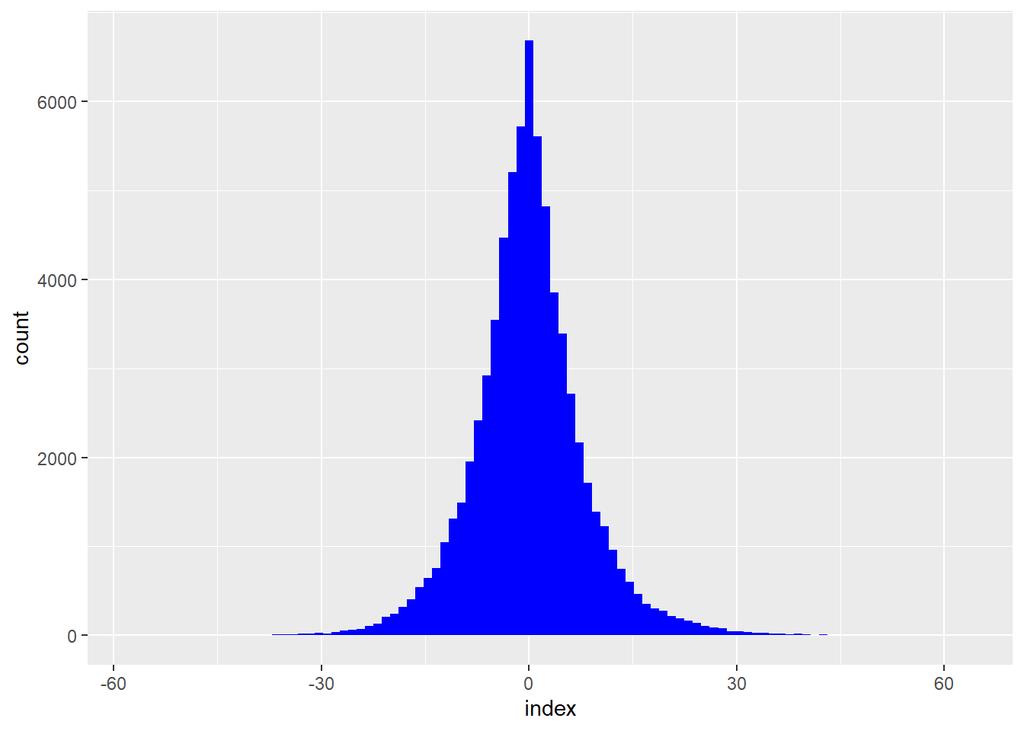

```r
final_df_clean %>% ggplot(mapping = aes(index)) +
  geom_histogram(bins = 100, fill="blue")
```

-The second important finding was that there is indeed a patern over the timing within each year, that directly impacts interest

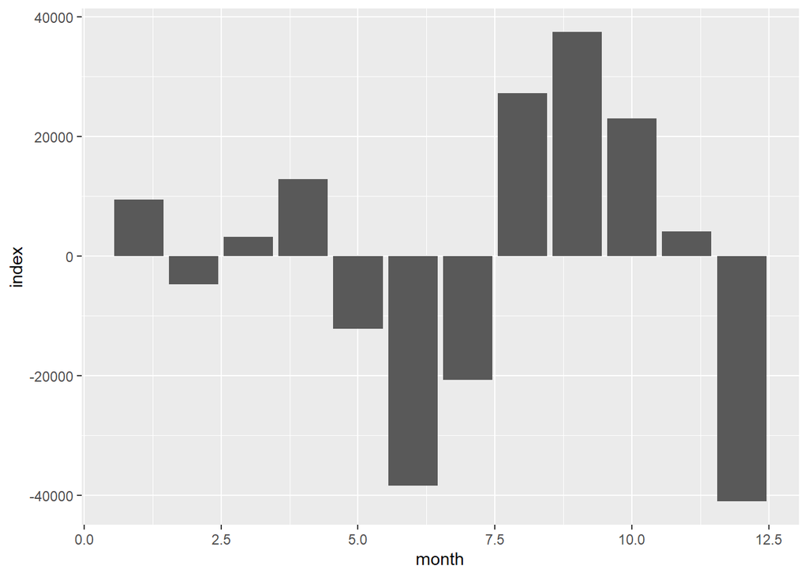

```r
#paterns over months
grouped_month <-  final_df_clean %>% group_by(month) %>% summarize(index = sum(index, na.rm=TRUE))

grouped_month %>%
ggplot(mapping = aes(x=month, y =index)) +
  geom_col()
```

**Comments**

```
- This visual portrays that the highest time for searching for colleges (max interest) is in September and the lowest time of interest is in December.
-This makes sense as September is when School starts for most folks, and is also a common time for students looking to get into college next year to be begin search. December is winter break, and very few individual's would be looking at potential schools during that time.
- This visual indicates that we should have a time control in our model, which we will build below.
```

The last visual of interest is comparing the interest in high and low earning colleges over time:

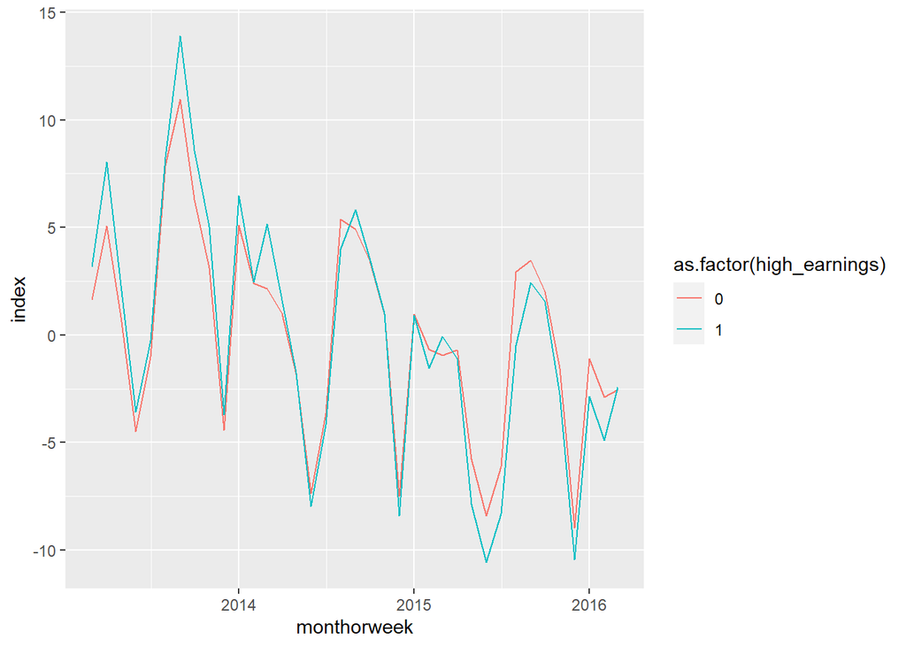

```r
final_df_clean %>% group_by(high_earnings, monthorweek) %>%  filter(high_earnings != 'NA') %>%
  summarise(index = mean(index)) %>%
  ggplot(mapping = aes(x = monthorweek, y = index, color = as.factor(high_earnings))) +
  geom_line()
```

**Comments**

[output not shown]